# Bellabeat Fitness Data Analysis

Hamza Jawad

2025-09-09

# 1 Introduction

This report presents a comprehensive analysis of **Bellabeat fitness tracker data**, following the structured data analysis process:

- **Ask Phase**: Define the business objectives and questions
- **Prepare Phase**: Import and explore the fitness datasets
- **Process Phase**: Clean and transform the datasets
- **Analyze Phase**: Generate descriptive statistics and insights
- **Share Phase**: Visualize and communicate key findings

# 2 Ask Phase

### 2.0.1 Business Task:

Analyze user engagement patterns, health behaviors, and fitness trends from smart device usage data to inform Bellabeat’s marketing strategy.

### 2.0.2 Business Objective:

This project analyzes fitness tracker data from **March to May (2016)** to understand how users interact with Bellabeat products, identify engagement patterns, and uncover health behavior trends. The findings will guide marketing strategies to improve user retention and product adoption.

# 3 Prepare Phase

### 3.0.1 Load Required Libraries

```r
library(tidyverse)
library(lubridate)
library(janitor)
library(skimr)
library(scales)
library(dplyr)
library(readr)
library(ggplot2)
```

## 3.1 Import Datasets

### 3.1.1 March to April datasets

```r
daily_activity_1 <- read_csv("F:/Google_Data_Analysis/case_studies/case_study_2/case_study_2_datasets/raw_datasets/March_12--April_11/dailyActivity_merged.csv")
weight_log_1 <- read_csv("F:/Google_Data_Analysis/case_studies/case_study_2/case_study_2_datasets/raw_datasets/March_12--April_11/weightLogInfo_merged.csv")
heart_rate_1 <- read_csv("F:/Google_Data_Analysis/case_studies/case_study_2/case_study_2_datasets/raw_datasets/March_12--April_11/heartrate_seconds_merged.csv")
```

### 3.1.2 April to May datasets

```r
daily_activity_2 <- read_csv("F:/Google_Data_Analysis/case_studies/case_study_2/case_study_2_datasets/raw_datasets/April_12--May_12/dailyActivity_merged.csv")
weight_log_2 <- read_csv("F:/Google_Data_Analysis/case_studies/case_study_2/case_study_2_datasets/raw_datasets/April_12--May_12/weightLogInfo_merged.csv")
heart_rate_2 <- read_csv("F:/Google_Data_Analysis/case_studies/case_study_2/case_study_2_datasets/raw_datasets/April_12--May_12/heartrate_seconds_merged.csv")
```

### 3.1.3 Sleep dataset

```r
sleep_day <- read_csv("F:/Google_Data_Analysis/case_studies/case_study_2/case_study_2_datasets/raw_datasets/April_12--May_12/sleepDay_merged.csv")
```

## 3.2 Inspect the Datasets

### 3.2.1 Check first five rows of each dataset

```r
knitr::kable(head(daily_activity_1, 5))
```

| Id | ActivityDate | TotalSteps | TotalDistance | TrackerDistance | LoggedActivitiesDistance | VeryActiveDistance | ModeratelyActiveDistance | LightActiveDistance | SedentaryActiveDistance | VeryActiveMinutes | FairlyActiveMinutes | LightlyActiveMinutes | SedentaryMinutes | Calories |
| --- | --- | --- | --- | --- | --- | --- | --- | --- | --- | --- | --- | --- | --- | --- |
| 1503960366 | 3/25/2016 | 11004 | 7.11 | 7.11 | 0 | 2.57 | 0.46 | 4.07 | 0 | 33 | 12 | 205 | 804 | 1819 |
| 1503960366 | 3/26/2016 | 17609 | 11.55 | 11.55 | 0 | 6.92 | 0.73 | 3.91 | 0 | 89 | 17 | 274 | 588 | 2154 |
| 1503960366 | 3/27/2016 | 12736 | 8.53 | 8.53 | 0 | 4.66 | 0.16 | 3.71 | 0 | 56 | 5 | 268 | 605 | 1944 |
| 1503960366 | 3/28/2016 | 13231 | 8.93 | 8.93 | 0 | 3.19 | 0.79 | 4.95 | 0 | 39 | 20 | 224 | 1080 | 1932 |
| 1503960366 | 3/29/2016 | 12041 | 7.85 | 7.85 | 0 | 2.16 | 1.09 | 4.61 | 0 | 28 | 28 | 243 | 763 | 1886 |

```r
knitr::kable(head(weight_log_1, 5))
```

| Id | Date | WeightKg | WeightPounds | Fat | BMI | IsManualReport | LogId |
| --- | --- | --- | --- | --- | --- | --- | --- |
| 1503960366 | 4/5/2016 11:59:59 PM | 53.3 | 117.5064 | 22 | 22.97 | TRUE | 1.459901e+12 |
| 1927972279 | 4/10/2016 6:33:26 PM | 129.6 | 285.7191 | NA | 46.17 | FALSE | 1.460313e+12 |
| 2347167796 | 4/3/2016 11:59:59 PM | 63.4 | 139.7731 | 10 | 24.77 | TRUE | 1.459728e+12 |
| 2873212765 | 4/6/2016 11:59:59 PM | 56.7 | 125.0021 | NA | 21.45 | TRUE | 1.459987e+12 |
| 2873212765 | 4/7/2016 11:59:59 PM | 57.2 | 126.1044 | NA | 21.65 | TRUE | 1.460074e+12 |

```r
knitr::kable(head(heart_rate_1, 5))
```

| Id | Time | Value |
| --- | --- | --- |
| 2022484408 | 4/1/2016 7:54:00 AM | 93 |
| 2022484408 | 4/1/2016 7:54:05 AM | 91 |
| 2022484408 | 4/1/2016 7:54:10 AM | 96 |
| 2022484408 | 4/1/2016 7:54:15 AM | 98 |
| 2022484408 | 4/1/2016 7:54:20 AM | 100 |

```r
knitr::kable(head(sleep_day, 5))
```

| Id | SleepDay | TotalSleepRecords | TotalMinutesAsleep | TotalTimeInBed |
| --- | --- | --- | --- | --- |
| 1503960366 | 4/12/2016 12:00:00 AM | 1 | 327 | 346 |
| 1503960366 | 4/13/2016 12:00:00 AM | 2 | 384 | 407 |
| 1503960366 | 4/15/2016 12:00:00 AM | 1 | 412 | 442 |
| 1503960366 | 4/16/2016 12:00:00 AM | 2 | 340 | 367 |
| 1503960366 | 4/17/2016 12:00:00 AM | 1 | 700 | 712 |

### 3.2.2 Check structure of each dataset

```r
str(daily_activity_1)
```

```
## spc_tbl_ [457 × 15] (S3: spec_tbl_df/tbl_df/tbl/data.frame)
##  $ Id                      : num [1:457] 1.5e+09 1.5e+09 1.5e+09 1.5e+09 1.5e+09 ...
##  $ ActivityDate            : chr [1:457] "3/25/2016" "3/26/2016" "3/27/2016" "3/28/2016" ...
##  $ TotalSteps              : num [1:457] 11004 17609 12736 13231 12041 ...
##  $ TotalDistance           : num [1:457] 7.11 11.55 8.53 8.93 7.85 ...
##  $ TrackerDistance         : num [1:457] 7.11 11.55 8.53 8.93 7.85 ...
##  $ LoggedActivitiesDistance: num [1:457] 0 0 0 0 0 0 0 0 0 0 ...
##  $ VeryActiveDistance      : num [1:457] 2.57 6.92 4.66 3.19 2.16 ...
##  $ ModeratelyActiveDistance: num [1:457] 0.46 0.73 0.16 0.79 1.09 ...
##  $ LightActiveDistance     : num [1:457] 4.07 3.91 3.71 4.95 4.61 ...
##  $ SedentaryActiveDistance : num [1:457] 0 0 0 0 0 0 0 0 0 0 ...
##  $ VeryActiveMinutes       : num [1:457] 33 89 56 39 28 30 33 47 40 15 ...
##  $ FairlyActiveMinutes     : num [1:457] 12 17 5 20 28 13 12 21 11 30 ...
##  $ LightlyActiveMinutes    : num [1:457] 205 274 268 224 243 223 239 200 244 314 ...
##  $ SedentaryMinutes        : num [1:457] 804 588 605 1080 763 ...
##  $ Calories                : num [1:457] 1819 2154 1944 1932 1886 ...
##  - attr(*, "spec")=
##   .. cols(
##   ..   Id = col_double(),
##   ..   ActivityDate = col_character(),
##   ..   TotalSteps = col_double(),
##   ..   TotalDistance = col_double(),
##   ..   TrackerDistance = col_double(),
##   ..   LoggedActivitiesDistance = col_double(),
##   ..   VeryActiveDistance = col_double(),
##   ..   ModeratelyActiveDistance = col_double(),
##   ..   LightActiveDistance = col_double(),
##   ..   SedentaryActiveDistance = col_double(),
##   ..   VeryActiveMinutes = col_double(),
##   ..   FairlyActiveMinutes = col_double(),
##   ..   LightlyActiveMinutes = col_double(),
##   ..   SedentaryMinutes = col_double(),
##   ..   Calories = col_double()
##   .. )
##  - attr(*, "problems")=<externalptr>
```

```r
str(weight_log_1)
```

```
## spc_tbl_ [33 × 8] (S3: spec_tbl_df/tbl_df/tbl/data.frame)
##  $ Id            : num [1:33] 1.50e+09 1.93e+09 2.35e+09 2.87e+09 2.87e+09 ...
##  $ Date          : chr [1:33] "4/5/2016 11:59:59 PM" "4/10/2016 6:33:26 PM" "4/3/2016 11:59:59 PM" "4/6/2016 11:59:59 PM" ...
##  $ WeightKg      : num [1:33] 53.3 129.6 63.4 56.7 57.2 ...
##  $ WeightPounds  : num [1:33] 118 286 140 125 126 ...
##  $ Fat           : num [1:33] 22 NA 10 NA NA NA NA NA NA NA ...
##  $ BMI           : num [1:33] 23 46.2 24.8 21.5 21.6 ...
##  $ IsManualReport: logi [1:33] TRUE FALSE TRUE TRUE TRUE TRUE ...
##  $ LogId         : num [1:33] 1.46e+12 1.46e+12 1.46e+12 1.46e+12 1.46e+12 ...
##  - attr(*, "spec")=
##   .. cols(
##   ..   Id = col_double(),
##   ..   Date = col_character(),
##   ..   WeightKg = col_double(),
##   ..   WeightPounds = col_double(),
##   ..   Fat = col_double(),
##   ..   BMI = col_double(),
##   ..   IsManualReport = col_logical(),
##   ..   LogId = col_double()
##   .. )
##  - attr(*, "problems")=<externalptr>
```

```r
str(heart_rate_1)
```

```
## spc_tbl_ [1,154,681 × 3] (S3: spec_tbl_df/tbl_df/tbl/data.frame)
##  $ Id   : num [1:1154681] 2.02e+09 2.02e+09 2.02e+09 2.02e+09 2.02e+09 ...
##  $ Time : chr [1:1154681] "4/1/2016 7:54:00 AM" "4/1/2016 7:54:05 AM" "4/1/2016 7:54:10 AM" "4/1/2016 7:54:15 AM" ...
##  $ Value: num [1:1154681] 93 91 96 98 100 101 104 105 102 106 ...
##  - attr(*, "spec")=
##   .. cols(
##   ..   Id = col_double(),
##   ..   Time = col_character(),
##   ..   Value = col_double()
##   .. )
##  - attr(*, "problems")=<externalptr>
```

```r
str(sleep_day)
```

```
## spc_tbl_ [413 × 5] (S3: spec_tbl_df/tbl_df/tbl/data.frame)
##  $ Id                : num [1:413] 1.5e+09 1.5e+09 1.5e+09 1.5e+09 1.5e+09 ...
##  $ SleepDay          : chr [1:413] "4/12/2016 12:00:00 AM" "4/13/2016 12:00:00 AM" "4/15/2016 12:00:00 AM" "4/16/2016 12:00:00 AM" ...
##  $ TotalSleepRecords : num [1:413] 1 2 1 2 1 1 1 1 1 1 ...
##  $ TotalMinutesAsleep: num [1:413] 327 384 412 340 700 304 360 325 361 430 ...
##  $ TotalTimeInBed    : num [1:413] 346 407 442 367 712 320 377 364 384 449 ...
##  - attr(*, "spec")=
##   .. cols(
##   ..   Id = col_double(),
##   ..   SleepDay = col_character(),
##   ..   TotalSleepRecords = col_double(),
##   ..   TotalMinutesAsleep = col_double(),
##   ..   TotalTimeInBed = col_double()
##   .. )
##  - attr(*, "problems")=<externalptr>
```

### 3.2.3 Get a summary overview

```r
skim_without_charts(daily_activity_1)
```

Data summary

| Name | daily_activity_1 |
| --- | --- |
| Number of rows | 457 |
| Number of columns | 15 |
| _______________________ |  |
| Column type frequency: |  |
| character | 1 |
| numeric | 14 |
| ________________________ |  |
| Group variables | None |

**Variable type: character**

| skim_variable | n_missing | complete_rate | min | max | empty | n_unique | whitespace |
| --- | --- | --- | --- | --- | --- | --- | --- |
| ActivityDate | 0 | 1 | 8 | 9 | 0 | 32 | 0 |

**Variable type: numeric**

| skim_variable | n_missing | complete_rate | mean | sd | p0 | p25 | p50 | p75 | p100 |
| --- | --- | --- | --- | --- | --- | --- | --- | --- | --- |
| Id | 0 | 1 | 4.628595e+09 | 2.293781e+09 | 1503960366 | 2.347168e+09 | 4.057193e+09 | 6.391747e+09 | 8.877689e+09 |
| TotalSteps | 0 | 1 | 6.546560e+03 | 5.398490e+03 | 0 | 1.988000e+03 | 5.986000e+03 | 1.019800e+04 | 2.849700e+04 |
| TotalDistance | 0 | 1 | 4.660000e+00 | 4.080000e+00 | 0 | 1.410000e+00 | 4.090000e+00 | 7.160000e+00 | 2.753000e+01 |
| TrackerDistance | 0 | 1 | 4.610000e+00 | 4.070000e+00 | 0 | 1.280000e+00 | 4.090000e+00 | 7.110000e+00 | 2.753000e+01 |
| LoggedActivitiesDistance | 0 | 1 | 1.800000e-01 | 8.500000e-01 | 0 | 0.000000e+00 | 0.000000e+00 | 0.000000e+00 | 6.730000e+00 |
| VeryActiveDistance | 0 | 1 | 1.180000e+00 | 2.490000e+00 | 0 | 0.000000e+00 | 0.000000e+00 | 1.310000e+00 | 2.192000e+01 |
| ModeratelyActiveDistance | 0 | 1 | 4.800000e-01 | 8.300000e-01 | 0 | 0.000000e+00 | 2.000000e-02 | 6.700000e-01 | 6.400000e+00 |
| LightActiveDistance | 0 | 1 | 2.890000e+00 | 2.240000e+00 | 0 | 8.700000e-01 | 2.930000e+00 | 4.460000e+00 | 1.251000e+01 |
| SedentaryActiveDistance | 0 | 1 | 0.000000e+00 | 1.000000e-02 | 0 | 0.000000e+00 | 0.000000e+00 | 0.000000e+00 | 1.000000e-01 |
| VeryActiveMinutes | 0 | 1 | 1.662000e+01 | 2.892000e+01 | 0 | 0.000000e+00 | 0.000000e+00 | 2.500000e+01 | 2.020000e+02 |
| FairlyActiveMinutes | 0 | 1 | 1.307000e+01 | 3.621000e+01 | 0 | 0.000000e+00 | 1.000000e+00 | 1.600000e+01 | 6.600000e+02 |
| LightlyActiveMinutes | 0 | 1 | 1.700700e+02 | 1.222100e+02 | 0 | 6.400000e+01 | 1.810000e+02 | 2.570000e+02 | 7.200000e+02 |
| SedentaryMinutes | 0 | 1 | 9.952800e+02 | 3.370200e+02 | 32 | 7.280000e+02 | 1.057000e+03 | 1.285000e+03 | 1.440000e+03 |
| Calories | 0 | 1 | 2.189450e+03 | 8.154800e+02 | 0 | 1.776000e+03 | 2.062000e+03 | 2.667000e+03 | 4.562000e+03 |

```r
skim_without_charts(weight_log_1)
```

Data summary

| Name | weight_log_1 |
| --- | --- |
| Number of rows | 33 |
| Number of columns | 8 |
| _______________________ |  |
| Column type frequency: |  |
| character | 1 |
| logical | 1 |
| numeric | 6 |
| ________________________ |  |
| Group variables | None |

**Variable type: character**

| skim_variable | n_missing | complete_rate | min | max | empty | n_unique | whitespace |
| --- | --- | --- | --- | --- | --- | --- | --- |
| Date | 0 | 1 | 19 | 21 | 0 | 24 | 0 |

**Variable type: logical**

| skim_variable | n_missing | complete_rate | mean | count |
| --- | --- | --- | --- | --- |
| IsManualReport | 0 | 1 | 0.7 | TRU: 23, FAL: 10 |

**Variable type: numeric**

| skim_variable | n_missing | complete_rate | mean | sd | p0 | p25 | p50 | p75 | p100 |
| --- | --- | --- | --- | --- | --- | --- | --- | --- | --- |
| Id | 0 | 1.00 | 6.477156e+09 | 2.308888e+09 | 1.503960e+09 | 4.702922e+09 | 6.962181e+09 | 8.877689e+09 | 8.877689e+09 |
| WeightKg | 0 | 1.00 | 7.344000e+01 | 1.653000e+01 | 5.330000e+01 | 6.170000e+01 | 6.250000e+01 | 8.580000e+01 | 1.296000e+02 |
| WeightPounds | 0 | 1.00 | 1.619100e+02 | 3.644000e+01 | 1.175100e+02 | 1.360300e+02 | 1.377900e+02 | 1.891600e+02 | 2.857200e+02 |
| Fat | 31 | 0.06 | 1.600000e+01 | 8.490000e+00 | 1.000000e+01 | 1.300000e+01 | 1.600000e+01 | 1.900000e+01 | 2.200000e+01 |
| BMI | 0 | 1.00 | 2.573000e+01 | 4.330000e+00 | 2.145000e+01 | 2.410000e+01 | 2.439000e+01 | 2.576000e+01 | 4.617000e+01 |
| LogId | 0 | 1.00 | 1.459959e+12 | 3.088072e+08 | 1.459382e+12 | 1.459753e+12 | 1.459987e+12 | 1.460160e+12 | 1.460506e+12 |

```r
skim_without_charts(heart_rate_1)
```

Data summary

| Name | heart_rate_1 |
| --- | --- |
| Number of rows | 1154681 |
| Number of columns | 3 |
| _______________________ |  |
| Column type frequency: |  |
| character | 1 |
| numeric | 2 |
| ________________________ |  |
| Group variables | None |

**Variable type: character**

| skim_variable | n_missing | complete_rate | min | max | empty | n_unique | whitespace |
| --- | --- | --- | --- | --- | --- | --- | --- |
| Time | 0 | 1 | 19 | 21 | 0 | 510597 | 0 |

**Variable type: numeric**

| skim_variable | n_missing | complete_rate | mean | sd | p0 | p25 | p50 | p75 | p100 |
| --- | --- | --- | --- | --- | --- | --- | --- | --- | --- |
| Id | 0 | 1 | 5.352122e+09 | 2.033584e+09 | 2022484408 | 4020332650 | 5553957443 | 6962181067 | 8877689391 |
| Value | 0 | 1 | 7.976000e+01 | 1.873000e+01 | 36 | 66 | 77 | 90 | 185 |

```r
skim_without_charts(sleep_day)
```

Data summary

| Name | sleep_day |
| --- | --- |
| Number of rows | 413 |
| Number of columns | 5 |
| _______________________ |  |
| Column type frequency: |  |
| character | 1 |
| numeric | 4 |
| ________________________ |  |
| Group variables | None |

**Variable type: character**

| skim_variable | n_missing | complete_rate | min | max | empty | n_unique | whitespace |
| --- | --- | --- | --- | --- | --- | --- | --- |
| SleepDay | 0 | 1 | 20 | 21 | 0 | 31 | 0 |

**Variable type: numeric**

| skim_variable | n_missing | complete_rate | mean | sd | p0 | p25 | p50 | p75 | p100 |
| --- | --- | --- | --- | --- | --- | --- | --- | --- | --- |
| Id | 0 | 1 | 5.000979e+09 | 2.06036e+09 | 1503960366 | 3977333714 | 4702921684 | 6962181067 | 8792009665 |
| TotalSleepRecords | 0 | 1 | 1.120000e+00 | 3.50000e-01 | 1 | 1 | 1 | 1 | 3 |
| TotalMinutesAsleep | 0 | 1 | 4.194700e+02 | 1.18340e+02 | 58 | 361 | 433 | 490 | 796 |
| TotalTimeInBed | 0 | 1 | 4.586400e+02 | 1.27100e+02 | 61 | 403 | 463 | 526 | 961 |

# 4 Process Phase

## 4.1 Cleaning the Datasets

To prepare the fitness data for analysis, I applied the following steps across all datasets:

- Cleaned column names for consistency using **`janitor::clean_names()`**
- Converted date columns to proper **DateTime** format using **`lubridate`**
- Removed duplicates and irrelevant columns
- Handled missing values and unrealistic data points
- Performed data integrity checks for consistency
- Created new features for engagement analysis
- Merged time-period datasets for comprehensive analysis

## 4.2 March to April Daily Activity Dataset Cleaning

```r
daily_activity_1 <- daily_activity_1 %>%
  clean_names() %>%
  mutate(activity_date = mdy(activity_date)) %>%
  distinct() %>%
  select(-logged_activities_distance, -sedentary_active_distance)

# Data quality check
daily_activity_1 %>%
  mutate(check_distance = very_active_distance +
           moderately_active_distance +
           light_active_distance) %>%
  summarise(match_rate = mean(abs(check_distance - total_distance) < 0.01))
```

```
## # A tibble: 1 × 1
##   match_rate
##        <dbl>
## 1      0.751
```

```r
colSums(is.na(daily_activity_1))
```

```
##                         id              activity_date
##                          0                          0
##                total_steps             total_distance
##                          0                          0
##           tracker_distance       very_active_distance
##                          0                          0
## moderately_active_distance      light_active_distance
##                          0                          0
##        very_active_minutes      fairly_active_minutes
##                          0                          0
##     lightly_active_minutes          sedentary_minutes
##                          0                          0
##                   calories
##                          0
```

```r
n_distinct(daily_activity_1$id)
```

```
## [1] 35
```

```r
range(daily_activity_1$activity_date)
```

```
## [1] "2016-03-12" "2016-04-12"
```

```r
daily_activity_1 %>%
  summarise(max_steps = max(total_steps),
            min_steps = min(total_steps),
            max_calories = max(calories),
            min_calories = min(calories))
```

```
## # A tibble: 1 × 4
##   max_steps min_steps max_calories min_calories
##       <dbl>     <dbl>        <dbl>        <dbl>
## 1     28497         0         4562            0
```

```r
# Remove unrealistic values
daily_activity_1 <- daily_activity_1 %>%
  filter(total_steps > 0 & calories > 0)

# Feature engineering
daily_activity_1 <- daily_activity_1 %>%
  mutate(
    weekday = weekdays(activity_date),
    active_minutes_total = very_active_minutes + fairly_active_minutes + lightly_active_minutes,
    engagement_level = case_when(
      total_steps < 5000 ~ "Low",
      total_steps < 10000 ~ "Moderate",
      TRUE ~ "High"
    )
  )

# Save cleaned dataset
write_csv(daily_activity_1,
          "F:/Google_Data_Analysis/case_studies/case_study_2/case_study_2_datasets/cleaned_datasets/daily_activity_clean_first.csv")
```

## 4.3 April to May Daily Activity Dataset Cleaning

```r
daily_activity_2 <- daily_activity_2 %>%
  clean_names() %>%
  mutate(activity_date = mdy(activity_date)) %>%
  distinct() %>%
  select(-logged_activities_distance, -sedentary_active_distance)

# Data quality check
daily_activity_2 %>%
  mutate(check_distance = very_active_distance +
           moderately_active_distance +
           light_active_distance) %>%
  summarise(match_rate = mean(abs(check_distance - total_distance) < 0.01))
```

```
## # A tibble: 1 × 1
##   match_rate
##        <dbl>
## 1      0.743
```

```r
colSums(is.na(daily_activity_2))
```

```
##                         id              activity_date
##                          0                          0
##                total_steps             total_distance
##                          0                          0
##           tracker_distance       very_active_distance
##                          0                          0
## moderately_active_distance      light_active_distance
##                          0                          0
##        very_active_minutes      fairly_active_minutes
##                          0                          0
##     lightly_active_minutes          sedentary_minutes
##                          0                          0
##                   calories
##                          0
```

```r
n_distinct(daily_activity_2$id)
```

```
## [1] 33
```

```r
range(daily_activity_2$activity_date)
```

```
## [1] "2016-04-12" "2016-05-12"
```

```r
daily_activity_2 %>%
  summarise(max_steps = max(total_steps),
            min_steps = min(total_steps),
            max_calories = max(calories),
            min_calories = min(calories))
```

```
## # A tibble: 1 × 4
##   max_steps min_steps max_calories min_calories
##       <dbl>     <dbl>        <dbl>        <dbl>
## 1     36019         0         4900            0
```

```r
# Remove unrealistic values
daily_activity_2 <- daily_activity_2 %>%
  filter(total_steps > 0 & calories > 0)

# Feature engineering
daily_activity_2 <- daily_activity_2 %>%
  mutate(
    weekday = weekdays(activity_date),
    active_minutes_total = very_active_minutes + fairly_active_minutes + lightly_active_minutes,
    engagement_level = case_when(
      total_steps < 5000 ~ "Low",
      total_steps < 10000 ~ "Moderate",
      TRUE ~ "High"
    )
  )

# Save cleaned dataset
write_csv(daily_activity_2,
          "F:/Google_Data_Analysis/case_studies/case_study_2/case_study_2_datasets/cleaned_datasets/daily_activity_clean_second.csv")
```

## 4.4 Merge March–April and April–May Daily Activity Datasets

```r
# Load both cleaned datasets
daily_activity_first <- read_csv("F:/Google_Data_Analysis/case_studies/case_study_2/case_study_2_datasets/cleaned_datasets/daily_activity_clean_first.csv")
daily_activity_second <- read_csv("F:/Google_Data_Analysis/case_studies/case_study_2/case_study_2_datasets/cleaned_datasets/daily_activity_clean_second.csv")

# Merge them into one dataframe
daily_activity_all <- bind_rows(daily_activity_first, daily_activity_second) %>%
  distinct()

# Verify merged dataset
nrow(daily_activity_all)
```

```
## [1] 1259
```

```r
n_distinct(daily_activity_all$id)
```

```
## [1] 35
```

```r
range(daily_activity_all$activity_date)
```

```
## [1] "2016-03-12" "2016-05-12"
```

```r
# Save final merged dataset
write_csv(daily_activity_all,
          "F:/Google_Data_Analysis/case_studies/case_study_2/case_study_2_datasets/cleaned_datasets/daily_activity_clean_all.csv")
```

## 4.5 March to April Weight Log Dataset Cleaning

```r
weight_log_1 <- weight_log_1 %>%
  clean_names() %>%
  mutate(date = mdy_hms(date)) %>%
  distinct()

# Check missing values
colSums(is.na(weight_log_1))
```

```
##               id             date        weight_kg    weight_pounds
##                0                0                0                0
##              fat              bmi is_manual_report           log_id
##               31                0                0                0
```

```r
# Outlier detection
weight_log_1 %>%
  summarise(max_weight = max(weight_kg, na.rm = TRUE),
            min_weight = min(weight_kg, na.rm = TRUE),
            max_bmi = max(bmi, na.rm = TRUE),
            min_bmi = min(bmi, na.rm = TRUE))
```

```
## # A tibble: 1 × 4
##   max_weight min_weight max_bmi min_bmi
##        <dbl>      <dbl>   <dbl>   <dbl>
## 1       130.       53.3    46.2    21.5
```

```r
# Remove unrealistic values
weight_log_1 <- weight_log_1 %>%
  filter(bmi > 10 & bmi < 60)

# Save cleaned dataset
write_csv(weight_log_1,
          "F:/Google_Data_Analysis/case_studies/case_study_2/case_study_2_datasets/cleaned_datasets/weight_log_clean_first.csv")
```

## 4.6 April to May Weight Log Dataset Cleaning

```r
weight_log_2 <- weight_log_2 %>%
  clean_names() %>%
  mutate(date = mdy_hms(date)) %>%
  distinct()

# Check missing values
colSums(is.na(weight_log_2))
```

```
##               id             date        weight_kg    weight_pounds
##                0                0                0                0
##              fat              bmi is_manual_report           log_id
##               65                0                0                0
```

```r
# Outlier detection
weight_log_2 %>%
  summarise(max_weight = max(weight_kg, na.rm = TRUE),
            min_weight = min(weight_kg, na.rm = TRUE),
            max_bmi = max(bmi, na.rm = TRUE),
            min_bmi = min(bmi, na.rm = TRUE))
```

```
## # A tibble: 1 × 4
##   max_weight min_weight max_bmi min_bmi
##        <dbl>      <dbl>   <dbl>   <dbl>
## 1       134.       52.6    47.5    21.5
```

```r
# Remove unrealistic values
weight_log_2 <- weight_log_2 %>%
  filter(bmi > 10 & bmi < 60)

# Save cleaned dataset
write_csv(weight_log_2,
          "F:/Google_Data_Analysis/case_studies/case_study_2/case_study_2_datasets/cleaned_datasets/weight_log_clean_second.csv")
```

## 4.7 Merge March–April and April–May Weight Log Datasets

```r
# Load both cleaned files
weight_log_1 <- read_csv("F:/Google_Data_Analysis/case_studies/case_study_2/case_study_2_datasets/cleaned_datasets/weight_log_clean_first.csv")
weight_log_2 <- read_csv("F:/Google_Data_Analysis/case_studies/case_study_2/case_study_2_datasets/cleaned_datasets/weight_log_clean_second.csv")

# Merge datasets
weight_log_final <- bind_rows(weight_log_1, weight_log_2) %>%
  distinct()

# Check date range and unique users
range(weight_log_final$date)
```

```
## [1] "2016-03-30 23:59:59 UTC" "2016-05-12 23:59:59 UTC"
```

```r
n_distinct(weight_log_final$id)
```

```
## [1] 13
```

```r
# Save merged cleaned dataset
write_csv(weight_log_final,
          "F:/Google_Data_Analysis/case_studies/case_study_2/case_study_2_datasets/cleaned_datasets/weight_log_clean_final.csv")
```

## 4.8 March to April Heart Rate Log Cleaning

```r
heart_rate_1 <- heart_rate_1 %>%
  clean_names() %>%
  mutate(time = mdy_hms(time)) %>%
  distinct()

# Check missing values
colSums(is.na(heart_rate_1))
```

```
##    id  time value
##     0     0     0
```

```r
# Outlier detection
heart_rate_1 %>%
  summarise(min_hr = min(value, na.rm = TRUE),
            max_hr = max(value, na.rm = TRUE))
```

```
## # A tibble: 1 × 2
##   min_hr max_hr
##    <dbl>  <dbl>
## 1     36    185
```

```r
# Filter unrealistic HR values
heart_rate_1 <- heart_rate_1 %>%
  filter(value >= 40 & value <= 220)

# Save cleaned dataset
write_csv(heart_rate_1,
          "F:/Google_Data_Analysis/case_studies/case_study_2/case_study_2_datasets/cleaned_datasets/heart_rate_clean_first.csv")
```

## 4.9 April to May Heart Rate Log Cleaning

```r
heart_rate_2 <- heart_rate_2 %>%
  clean_names() %>%
  mutate(time = mdy_hms(time)) %>%
  distinct()

# Check missing values
colSums(is.na(heart_rate_2))
```

```
##    id  time value
##     0     0     0
```

```r
# Outlier detection
heart_rate_2 %>%
  summarise(min_hr = min(value, na.rm = TRUE),
            max_hr = max(value, na.rm = TRUE))
```

```
## # A tibble: 1 × 2
##   min_hr max_hr
##    <dbl>  <dbl>
## 1     36    203
```

```r
# Filter unrealistic HR values
heart_rate_2 <- heart_rate_2 %>%
  filter(value >= 40 & value <= 220)

# Save cleaned dataset
write_csv(heart_rate_2,
          "F:/Google_Data_Analysis/case_studies/case_study_2/case_study_2_datasets/cleaned_datasets/heart_rate_clean_second.csv")
```

## 4.10 Merge Cleaned Heart Rate Files

```r
# Load both cleaned datasets
heart_rate_1 <- read_csv("F:/Google_Data_Analysis/case_studies/case_study_2/case_study_2_datasets/cleaned_datasets/heart_rate_clean_first.csv")
heart_rate_2 <- read_csv("F:/Google_Data_Analysis/case_studies/case_study_2/case_study_2_datasets/cleaned_datasets/heart_rate_clean_second.csv")

# Merge datasets
heart_rate_final <- bind_rows(heart_rate_1, heart_rate_2) %>%
  distinct()

# Save merged dataset
write_csv(heart_rate_final,
          "F:/Google_Data_Analysis/case_studies/case_study_2/case_study_2_datasets/cleaned_datasets/heart_rate_clean_final.csv")
```

## 4.11 Sleep Day Dataset Cleaning

```r
sleep_day <- sleep_day %>%
  clean_names() %>%
  mutate(sleep_day = mdy_hms(sleep_day)) %>%
  distinct() %>%
  filter(
    total_minutes_asleep >= 120 & total_minutes_asleep <= 960,
    total_time_in_bed >= 120 & total_time_in_bed <= 1100,
    total_minutes_asleep <= total_time_in_bed
  ) %>%
  mutate(
    sleep_efficiency = round((total_minutes_asleep / total_time_in_bed) * 100, 1),
    awake_minutes = total_time_in_bed - total_minutes_asleep,
    weekday = weekdays(sleep_day)
  )

# Save cleaned dataset
write_csv(sleep_day,
          "F:/Google_Data_Analysis/case_studies/case_study_2/case_study_2_datasets/cleaned_datasets/sleep_day_clean.csv")
```

# 5 Analyze Phase

After cleaning and merging all datasets, I performed comprehensive analyses to understand user engagement patterns, health behaviors, and fitness trends.

## 5.1 Import Cleaned Datasets

```r
daily_activity <- read_csv("F:/Google_Data_Analysis/case_studies/case_study_2/case_study_2_datasets/cleaned_datasets/daily_activity_clean_all.csv")
weight_log <- read_csv("F:/Google_Data_Analysis/case_studies/case_study_2/case_study_2_datasets/cleaned_datasets/weight_log_clean_final.csv")
heart_rate <- read_csv("F:/Google_Data_Analysis/case_studies/case_study_2/case_study_2_datasets/cleaned_datasets/heart_rate_clean_final.csv")
sleep_day <- read_csv("F:/Google_Data_Analysis/case_studies/case_study_2/case_study_2_datasets/cleaned_datasets/sleep_day_clean.csv")
```

## 5.2 Daily Activity Analysis (Engagement Patterns)

```r
engagement_summary <- daily_activity %>%
  group_by(engagement_level) %>%
  summarize(
    avg_steps = mean(total_steps, na.rm = TRUE),
    avg_active_minutes = mean(active_minutes_total, na.rm = TRUE),
    avg_calories = mean(calories, na.rm = TRUE),
    avg_sedentary = mean(sedentary_minutes, na.rm = TRUE),
    user_count = n_distinct(id),
    .groups = "drop"
  )

steps_calories_corr <- cor(daily_activity$total_steps,
                           daily_activity$calories,
                           use = "complete.obs")

sedentary_trend <- daily_activity %>%
  group_by(weekday) %>%
  summarize(avg_sedentary = mean(sedentary_minutes, na.rm = TRUE), .groups = "drop")
```

## 5.3 Sleep Data Analysis (Wellness & Lifestyle Habits)

```r
sleep_summary <- sleep_day %>%
  summarize(
    avg_sleep_hours = mean(total_minutes_asleep, na.rm = TRUE) / 60,
    avg_efficiency  = mean(sleep_efficiency, na.rm = TRUE),
    min_efficiency  = min(sleep_efficiency, na.rm = TRUE),
    max_efficiency  = max(sleep_efficiency, na.rm = TRUE)
  )

sleep_weekday <- sleep_day %>%
  group_by(weekday) %>%
  summarize(
    avg_sleep_hours = mean(total_minutes_asleep, na.rm = TRUE) / 60,
    avg_eff         = mean(sleep_efficiency, na.rm = TRUE),
    .groups = "drop"
  )

sleep_correlation <- cor(sleep_day$total_time_in_bed,
                         sleep_day$total_minutes_asleep,
                         use = "complete.obs")
```

## 5.4 Weight Log Analysis (Health-conscious Segments)

```r
bmi_summary <- weight_log %>%
  summarize(
    avg_bmi = mean(bmi, na.rm = TRUE),
    max_bmi = max(bmi, na.rm = TRUE),
    min_bmi = min(bmi, na.rm = TRUE)
  )

manual_logs <- weight_log %>%
  count(is_manual_report) %>%
  mutate(perc = n / sum(n) * 100)
```

## 5.5 Heart Rate Analysis (Stress & Activity)

```r
heart_rate_daily <- heart_rate %>%
  mutate(date = as.Date(time)) %>%
  group_by(id, date) %>%
  summarize(
    avg_hr = mean(value, na.rm = TRUE),
    max_hr = max(value, na.rm = TRUE),
    min_hr = min(value, na.rm = TRUE),
    .groups = "drop"
  )

hr_summary <- heart_rate_daily %>%
  summarize(
    overall_avg_hr = mean(avg_hr, na.rm = TRUE),
    resting_min    = min(min_hr, na.rm = TRUE),
    resting_max    = max(max_hr, na.rm = TRUE)
  )
```

## 5.6 Cross-Dataset Insights (Marketing Value)

```r
safe_cor <- function(x, y) {
  if (sum(complete.cases(x, y)) > 1) {
    return(cor(x, y, use = "complete.obs"))
  } else {
    return(NA)
  }
}

activity_sleep <- daily_activity %>%
  left_join(sleep_day, by = c("id" = "id", "activity_date" = "sleep_day"))

cor_steps_sleep <- safe_cor(activity_sleep$total_steps, activity_sleep$total_minutes_asleep)

activity_weight <- daily_activity %>%
  left_join(weight_log, by = c("id" = "id", "activity_date" = "date"))

cor_calories_bmi <- safe_cor(activity_weight$calories, activity_weight$bmi)

activity_hr <- daily_activity %>%
  left_join(heart_rate_daily, by = c("id" = "id", "activity_date" = "date"))

cor_activity_hr <- safe_cor(activity_hr$total_steps, activity_hr$avg_hr)
```

## 5.7 Print Key Results

```r
cat("---- Daily Activity Summary ----\n")
```

```
## ---- Daily Activity Summary ----
```

```r
print(engagement_summary)
```

```
## # A tibble: 3 × 6
##   engagement_level avg_steps avg_active_minutes avg_calories avg_sedentary
##   <chr>                <dbl>              <dbl>        <dbl>         <dbl>
## 1 High                13369.               318.        2719.          884.
## 2 Low                  2670.               122.        1829.         1025.
## 3 Moderate             7401.               265.        2379.          957.
## # ℹ 1 more variable: user_count <int>
```

```r
cat("Steps vs Calories Correlation:", round(steps_calories_corr, 3), "\n")
```

```
## Steps vs Calories Correlation: 0.562
```

```r
print(sedentary_trend)
```

```
## # A tibble: 7 × 2
##   weekday   avg_sedentary
##   <chr>             <dbl>
## 1 Friday             990.
## 2 Monday             988.
## 3 Saturday           928.
## 4 Sunday             949.
## 5 Thursday           940.
## 6 Tuesday            910.
## 7 Wednesday          961.
```

```r
cat("\n---- Sleep Summary ----\n")
```

```
##
## ---- Sleep Summary ----
```

```r
print(sleep_summary)
```

```
## # A tibble: 1 × 4
##   avg_sleep_hours avg_efficiency min_efficiency max_efficiency
##             <dbl>          <dbl>          <dbl>          <dbl>
## 1            7.20           91.6           49.8           99.8
```

```r
print(sleep_weekday)
```

```
## # A tibble: 7 × 3
##   weekday   avg_sleep_hours avg_eff
##   <chr>               <dbl>   <dbl>
## 1 Friday               7.04    91.8
## 2 Monday               7.25    91.8
## 3 Saturday             7.42    91.2
## 4 Sunday               7.89    90.4
## 5 Thursday             6.87    92.3
## 6 Tuesday              6.82    91.2
## 7 Wednesday            7.24    92.1
```

```r
cat("Sleep correlation (time in bed vs asleep):", round(sleep_correlation, 3), "\n")
```

```
## Sleep correlation (time in bed vs asleep): 0.899
```

```r
cat("\n---- Weight Log Summary ----\n")
```

```
##
## ---- Weight Log Summary ----
```

```r
print(bmi_summary)
```

```
## # A tibble: 1 × 3
##   avg_bmi max_bmi min_bmi
##     <dbl>   <dbl>   <dbl>
## 1    25.4    47.5    21.5
```

```r
print(manual_logs)
```

```
## # A tibble: 2 × 3
##   is_manual_report     n  perc
##   <lgl>            <int> <dbl>
## 1 FALSE               35  35.7
## 2 TRUE                63  64.3
```

```r
cat("\n---- Heart Rate Summary ----\n")
```

```
##
## ---- Heart Rate Summary ----
```

```r
print(hr_summary)
```

```
## # A tibble: 1 × 3
##   overall_avg_hr resting_min resting_max
##            <dbl>       <dbl>       <dbl>
## 1           79.0          40         203
```

```r
cat("\n---- Cross Dataset Correlations ----\n")
```

```
##
## ---- Cross Dataset Correlations ----
```

```r
cat("Activity vs Sleep correlation:", round(cor_steps_sleep, 3), "\n")
```

```
## Activity vs Sleep correlation: -0.276
```

```r
cat("Calories vs BMI correlation:", round(cor_calories_bmi, 3), "\n")
```

```
## Calories vs BMI correlation: NA
```

```r
cat("Steps vs Avg HR correlation:", round(cor_activity_hr, 3), "\n")
```

```
## Steps vs Avg HR correlation: 0.239
```

# 6 Share Phase

## 6.1 Custom Visualization Theme

```r
custom_theme <- theme_minimal(base_size = 14) +
  theme(
    plot.title = element_text(face = "bold", size = 16, hjust = 0.5),
    plot.subtitle = element_text(size = 12, hjust = 0.5, margin = margin(b = 10)),
    axis.title.x = element_text(face = "bold", size = 13, margin = margin(t = 10)),
    axis.title.y = element_text(face = "bold", size = 13, margin = margin(r = 10)),
    axis.text = element_text(size = 11),
    panel.grid.major = element_line(color = "grey85"),
    panel.grid.minor = element_blank()
  )

# Helper function to order weekdays
order_weekdays <- function(df, colname) {
  weekday_levels <- c("Monday", "Tuesday", "Wednesday", "Thursday", "Friday", "Saturday", "Sunday")
  df %>%
    mutate("{colname}" := factor(.data[[colname]], levels = weekday_levels))
}
```

## 6.2 Visualization 1: Steps vs Calories Burned

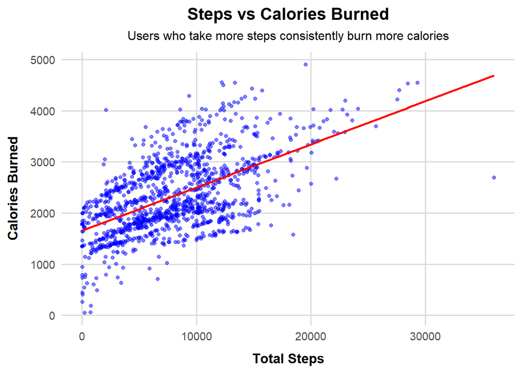

```r
ggplot(daily_activity, aes(x = total_steps, y = calories)) +
  geom_point(alpha = 0.5, color = "blue") +
  geom_smooth(method = "lm", se = FALSE, color = "red") +
  labs(
    title = "Steps vs Calories Burned",
    subtitle = "Users who take more steps consistently burn more calories",
    x = "Total Steps",
    y = "Calories Burned"
  ) +
  custom_theme
```

## 6.3 Visualization 2: Sedentary Behavior by Weekday

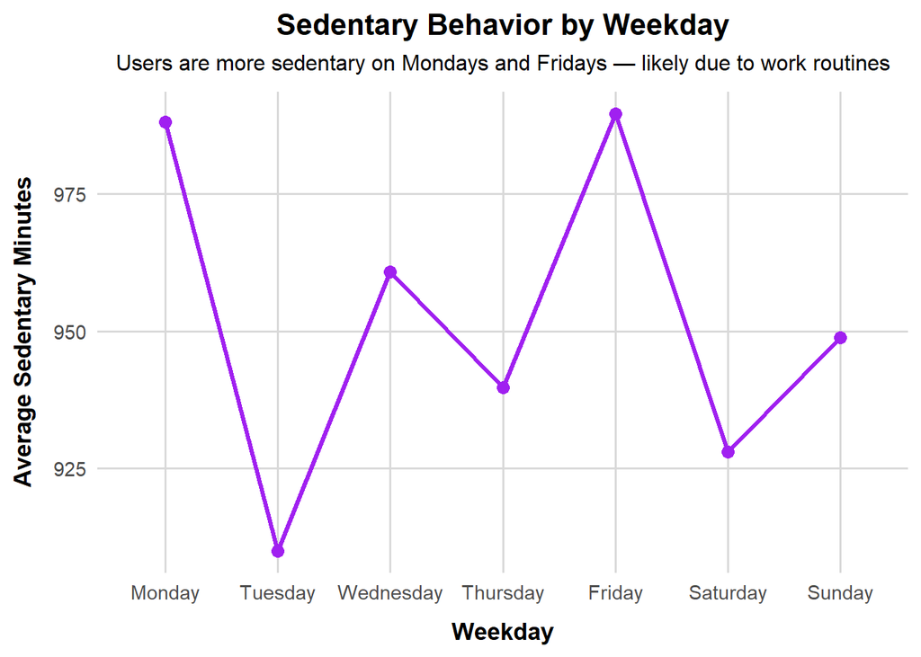

```r
sedentary_trend_plot <- daily_activity %>%
  group_by(weekday) %>%
  summarize(avg_sedentary = mean(sedentary_minutes, na.rm = TRUE), .groups = "drop") %>%
  order_weekdays("weekday")

ggplot(sedentary_trend_plot, aes(x = weekday, y = avg_sedentary, group = 1)) +
  geom_line(color = "purple", linewidth = 1.2) +
  geom_point(size = 3, color = "purple") +
  labs(
    title = "Sedentary Behavior by Weekday",
    subtitle = "Users are more sedentary on Mondays and Fridays — likely due to work routines",
    x = "Weekday",
    y = "Average Sedentary Minutes"
  ) +
  custom_theme
```

## 6.4 Visualization 3: Average Sleep Hours by Weekday

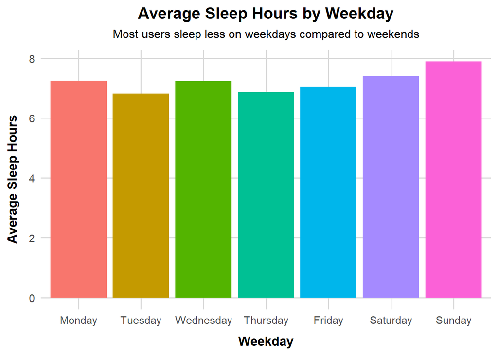

```r
sleep_weekday_plot <- sleep_day %>%
  group_by(weekday) %>%
  summarize(
    avg_sleep_hours = mean(total_minutes_asleep, na.rm = TRUE) / 60,
    avg_eff = mean(sleep_efficiency, na.rm = TRUE),
    .groups = "drop"
  ) %>%
  order_weekdays("weekday")

ggplot(sleep_weekday_plot, aes(x = weekday, y = avg_sleep_hours, fill = weekday)) +
  geom_col(show.legend = FALSE) +
  labs(
    title = "Average Sleep Hours by Weekday",
    subtitle = "Most users sleep less on weekdays compared to weekends",
    x = "Weekday",
    y = "Average Sleep Hours"
  ) +
  custom_theme
```